# Introduction

# Exceptions and debugging

This chapter describes techniques to use when things go wrong:

As with many other parts of R, the approach to dealing with errors and exceptions comes from a LISP-heritage, and is quite different (although some of the terminology is the same) from that of languages like Java.

## Debugging

This section discusses how to debug from the command-line. Modern R guis, like Rstudio, also provide built in debugging tools. These are built on top of the tools I'll describe below but may be exposed in a more user friendly way that requires less typing.

### Traceback

The key function for performing a post-mortem on an error is `traceback`, which shows all the calls leading up to the error. Here's an example:

```r
f <- function() g()
g <- function() h()
h <- function() i()
i <- function() "a" + 1
f()
```

```
## Error: non-numeric argument to binary operator
```

```r
# Error in "a" + 1 : non-numeric argument to binary operator
traceback()
```

```
## No traceback available
```

```r
# 4: i() at #1
# 3: h() at #1
# 2: g() at #1
# 1: f()
```

This is very helpful to determine exactly where in a stack of calls an error occured. However, it's not so helpful if you have a recursive function, or other situations where the same function is called in multiple places:

```r
j <- function(i = 5) {
  if (i == 1) "a" + 1
  j(i - 1)
}
j()
# Error in "a" + 1 : non-numeric argument to binary operator
traceback()
# 5: j(i - 1) at #3
# 4: j(i - 1) at #3
# 3: j(i - 1) at #3
# 2: j(i - 1) at #3
# 1: j()
```

### Browser

Trackback can help you figure out where the error occurred, but to understand why the error occured and to fix it, it's often easier to explore interactively. `browser()` allows you to do this by pausing execution and returning you to an interactive state. Here you can run any regular R command, as well as some extra single letter commands:

- `c`: leave interactive debugging and continue execution
- `n`: execute the next step. Be careful if you have a variable named `n`: to print it you'll need to be explicit `print(n)`.
- `\n`: the default behaviour is the same as `c`, but this is somewhat dangerous as it makes it very easy to accidentally continue during debugging. I recommend `options(browserNLdisabled = TRUE)` so that a new line is simply ignored.
- `Q`: stops debugging, terminate the function and return to the global workspace
- `where`: prints stack trace of active calls (the interactive equivalent of `traceback`)

Don't forget that you can combine `if` statements with `browser()` to only debug when a certain situation occurs.

### Browsing arbitrary R code

As well as adding `browser()` yourself, there are two functions that will added it to code:

- `debug()` inserts a browser statement in the first line of the specified function. `undebug` will remove it, or you can use `debugonce` to insert a browser call for the next run, and have it automatically removed afterwards.
- `utils::setBreakpoint()` does the same thing, but instead inserts `browser()` in the function corresponding to the specified file name and line number.

These two functions are both special cases of `trace()`, which allows you to insert arbitrary code in any position in an existing function. The complement of `trace()` is `untrace()`. You can only perform one trace per function - subsequent traces will replace prior.

Locating warnings is a little trickier. The easiest way to turn it in an error with `options(warn = 2)` and then use the standard functions described above. Turn back to default behaviour with `options(warn = 0)`.

### Browsing on error

It's also possible to start `browser` automatically when an error occurs, by setting `options(error = browser)`. This will start the interactive debugger in the environment in which the error occurred. Other functions that you can supply to `error` are:

- `recover`: a step up from `browser`, as it allows you to drill down into any of the calls in the call stack. This is useful because often the cause of the error is a number of calls back - you're just seeing the consequences. This is the result of "fail-slow" code
- `dump.frames`: an equivalent to `recover` for non-interactive code. Will save an `rdata` file containing the nested environments where the error occurred. This allows you to later use `debugger` to re-create the error as if you had called `recover` from where the error occurred

```r
# Saves debugging info to file last.dump.rda
options(error = quote({dump.frames(to.file = TRUE); q()}))

# Then in an interactive R session:
print(load("last.dump.rda"))
debugger("last.dump")
```

- `NULL`: the default. Prints an error message and stops function execution. Use this to reset back to the regular behaviour.

Warnings are harder to track down because they don't provide any information about where they occured. Currently, the best way to debug them into turn them into errors using `options(warn = 2)`: then you can apply any of the techniques described above.

## Exceptions

The fine details of exceptions are not particularly well documented in R. If you want to learn more about the internals, I recommend the following two primary sources:

- [A prototype of a condition system for R](http://homepage.stat.uiowa.edu/%7Eluke/R/exceptions/simpcond.html) by Robert Gentleman and Luke Tierney. This is describes an early version of R's condition system. The implementation changed somewhat since this was written, but it provides a good overview of how the pieces fit together, and some motivation for the design.
- [Beyond Exception Handling: Conditions and Restarts](http://www.gigamonkeys.com/book/beyond-exception-handling-conditions-and-restarts.html) by Peter Seibel. This describes exception handling in LISP, but the ideas are basically the same in R, and it provides some more complicated use cases.

### Creation

You create errors in R with `stop()`.

### Basic error handling

Error handling is performed with the `try()` (simple) and `tryCatch()` (complex) functions. `try()` allows execution to continue even after an exception has occured. For example, normally if you run a function that throws an error, it terminates immediately and doesn't return a value:

```r
f1 <- function(x) {
  log(x)
  10
}
f1("x")
```

```
## Error: non-numeric argument to mathematical function
```

However, if you wrap the statement that creates the error in `try()`, the error message will still be printed but execution will continue:

```r
f2 <- function(x) {
  try(log(x))
  10
}
f2()
```

```
## [1] 10
```

Note that you pass larger blocks of code to `try()` by wrapping them in `{}`:

```r
try({
  a <- 1
  b <- "x"
  a + b
})
a
```

```
## [1] 1
```

```r
b
```

```
## [1] "x"
```

You can also capture the output of the `try()` function. If succesful, it will be the last result evaluated in the block (just like a function); if unsuccesful it will be an (invisible) object of class "try-error":

```r
success <- try(1 + 2)
failure <- try("a" + "b")
str(success)
```

```
##  num 3
```

```r
str(failure)
```

```
## Class 'try-error'  atomic [1:1] Error in "a" + "b" : non-numeric argument to binary operator
##
##   ..- attr(*, "condition")=List of 2
##   .. ..$ message: chr "non-numeric argument to binary operator"
##   .. ..$ call   : language "a" + "b"
##   .. ..- attr(*, "class")= chr [1:3] "simpleError" "error" "condition"
```

You can use the second argument to `try()`, `silent`, to suppress the printing of the error message.

`try()` is particularly useful when you're applying a function to multiple elements in a list:

```r
elements <- list(1:10, c(-1, 10), c(T, F), letters)
results <- lapply(elements, log)
```

```
## Error: non-numeric argument to mathematical function
```

```r
results <- lapply(elements, function(x) try(log(x)))
```

There isn't a built-in function for testing for this class, so we'll define one. Then you can easily find the locations of errors with `sapply()` (learn more about it in the functionals chapter), and extract the successes or look at the inputs that lead to failures.

```r
is.error <- function(x) inherits(x, "try-error")
succeeded <- !sapply(results, is.error)

# look at successful results
str(results[succeeded])
```

```
## List of 3
##  $ : num [1:10] 0 0.693 1.099 1.386 1.609 ...
##  $ : num [1:2] NaN 2.3
##  $ : num [1:2] 0 -Inf
```

```r
# look at inputs that failed
str(elements[!succeeded])
```

```
## List of 1
##  $ : chr [1:26] "a" "b" "c" "d" ...
```

Another useful `try()` idiom is setting a default value if an expression fails. Simply assign the default value outside the try block, and then run the risky code:

```r
default <- NULL
try(default <- read.csv("possibly-bad-input.csv"), silent = TRUE)
```

### Advanced error handling

`tryCatch` gives more control than `try`, but to understand how it works, we first need to learn a little about conditions, the S3 objects that represent errors, warnings and messages.

```r
is.condition <- function(x) inherits(x, "condition")
```

There are three convenience methods for creating errors, warnings and messages. All take two arguments: the `message` to display, and an optional `call` indicating where the condition was created

```r
e <- simpleError("My error", quote(f(x = 71)))
w <- simpleWarning("My warning")
m <- simpleMessage("My message")
```

There is one class of conditions that can't be generated directly: interrupts, which occur when the user presses Ctrl + Break, Escape, or Ctrl + C (depending on the platform) to terminate execution.

The components of a condition can be extracted with `conditionMessage` and `conditionCall`:

```r
conditionMessage(e)
```

```
## [1] "My error"
```

```r
conditionCall(e)
```

```
## f(x = 71)
```

```r
signalCondition(e)
```

```
## Error: My error
```

```r
signalCondition(w)
```

```
## Error: no 'restart' 'muffleWarning' found
```

```r
signalCondition(m)
```

```
## My message
```

To listen to signals, we have two tools: `tryCatch()` and `withCallingHandlers()`. `tryCatch()` is an exiting handler: it catches the condition, but the rest of the code after the exception is not run. `withCallingHandlers()` sets up calling handlers: it catches the condition, and then resumes execution of the code. We will focus first on `tryCatch()`.

The `tryCatch()` call has three arguments:

- `expr`: the code to run.
- `...`: a set of named arguments setting up error handlers. If an error occurs, `tryCatch` will call the first handler whose name matches one of the classes of the condition. The only useful names for built-in conditions are `interrupt`, `error`, `warning` and `message`.
- `finally`: code to run regardless of whether `expr` succeeds or fails. This is useful for clean up, as described below. All handlers have been turned off by the time the `finally` code is run, so errors will propagate as usual.

The following examples illustrate the basic properties of `tryCatch`:

```r
# Handlers are passed a single argument
tryCatch(stop("error"),
  error = function(...) list(...)
)
```

```r
# This argument is the signalled condition, so we'll call
# it c for short.

# If multiple handlers match, the first is used
tryCatch(stop("error"),
  error = function(c) "a",
  error = function(c) "b"
)
```

```
## [1] "a"
```

```r
# If multiple signals are nested, the the most internal is used first.
tryCatch(
  tryCatch(stop("error"), error = function(c) "a"),
  error = function(c) "b"
)
```

```
## [1] "a"
```

```r
# Uncaught signals propagate outwards.
tryCatch(
  tryCatch(stop("error")),
  error = function(c) "b"
)
```

```
## [1] "b"
```

```r
# The first handler that matches a class of the condition is used,
# not the "best" match:
a <- structure(list(message = "my error", call = quote(a)),
  class = c("a", "error", "condition"))

tryCatch(stop(a),
  error = function(c) "error",
  a = function(c) "a"
)
```

```
## [1] "error"
```

```r
tryCatch(stop(a),
  a = function(c) "a",
  error = function(c) "error"
)
```

```
## [1] "a"
```

```r
# No matter what happens, finally is run:
tryCatch(stop("error"),
  finally = print("Done."))
```

```
## Error: error
```

```
## [1] "Done."
```

```r
tryCatch(a <- 1,
  finally = print("Done."))
```

```
## [1] "Done."
```

```r
# Any errors that occur in the finally block are handled normally
a <- 1
tryCatch(a <- 2,
  finally = stop("Error!"))
```

```
## Error: Error!
```

What can handler functions do?

- Return a value.
- Pass the condition along, by re-signalling the error with `stop(c)`, or `signalCondition(c)` for non-error conditions.
- Kill the function completely and return to the top-level with `invokeRestart("abort")`
- Invoke another restart defined by `withRestarts()`.

We can write a simple version of `try` using `tryCatch`. The real version of `try` is considerably more complicated to preserve the usual error behaviour.

```r
try <- function(code, silent = FALSE) {
  tryCatch(code, error = function(c) {
    if (!silent) message("Error:", conditionMessage(c))
    invisible(structure(conditionMessage(c), class = "try-error"))
  })
}
try(1)
```

```
## [1] 1
```

```r
try(stop("Hi"))
```

```
## Error:Hi
```

```r
try(stop("Hi"), silent = TRUE)

rm(try)

withCallingHandlers({
  a <- 1
  stop("Error")
  a <- 2
}, error = function(c) {})
```

```
## Error: Error
```

### Using `tryCatch`

With the basics in place, we'll next develop some useful tools based the ideas we just learned about.

The `finally` argument to `tryCatch` is particularly useful for clean up, because it is always called, regardless of whether the code executed successfully or not. This is useful when you have:

- modified `options`, `par` or locale
- opened connections, or created temporary files and directories
- opened graphics devices
- changed the working directory
- modified environment variables

The following function changes the working directory, executes some code, and always resets the working directory back to what it was before, even if the code raises an error.

```r
in_dir <- function(path, code) {
  cur_dir <- getwd()
  tryCatch({
    setwd(path)
    force(code)
  }, finally = setwd(cur_dir))
}

getwd()
```

```
## [1] "/home/hesterj/adv-r/no_pandoc"
```

```r
in_dir(R.home(), dir())
```

```
##  [1] "bin"          "COPYING"      "etc"          "include"
##  [5] "lib"          "library"      "modules"      "NEWS"
##  [9] "NEWS.pdf"     "SVN-REVISION"
```

```r
getwd()
```

```
## [1] "/home/hesterj/adv-r/no_pandoc"
```

```r
in_dir(R.home(), stop("Error!"))
```

```
## Error: Error!
```

```r
getwd()
```

```
## [1] "/home/hesterj/adv-r/no_pandoc"
```

Another more casual way of cleaning up is the `on.exit` function, which is called when the function terminates. It's not as fine grained as `tryCatch`, but it's a bit less typing.

```r
in_dir <- function(path, code) {
  cur_dir <- getwd()
  on.exit(setwd(cur_dir))

  force(code)
}
```

If you're using multiple `on.exit` calls, make sure to set `add = TRUE`, otherwise they will replace the previous call. **Caution**: Unfortunately the default in `on.exit()` is `add = FALSE`, so that every time you run it, it overwrites existing exit expressions. Because of the way `on.exit()` is implemented, it's not possible to create a variant with `add = TRUE`, so you must be careful when using it.

### Exercises

1. Write a function that opens a graphics device, runs the supplied code, and closes the graphics device (always, regardless of whether or not the plotting code worked).

## Defensive programming

Defensive programming is the art of making code fail in a well-defined manner even when something unexpected occurs. There are two components of this art related to exceptions: raising exceptions as soon as you notice something has gone wrong, and responding to errors as cleanly as possible.

A general principle for errors is to "fail fast" - as soon as you figure out something as wrong, and your inputs are not as expected, you should raise an error. This is more work for you as the function author, but will make it easier for the user to debug because they get errors early on, not after unexpected input has passed through several functions and caused a problem.

There is a tension between interactive analysis and programming. When you a doing an analysis, you want R to do what you mean, and if it guesses wrong, then you'll discover it right away and can fix it. If you're creating a function, then you want to make it as robust as possible so that any problems become apparent right away (see fail fast below).

- Be explicit:
  - Check the types of inputs
  - Be explicit about missings:
  - Avoid functions that have non-standard evaluation rules (i.e `subset`, `with`, `transform`). These functions save you time when working interactively, but when they fail inside a function they usually don't return a useful error message.
- Avoid functions that can return different types of objects:
  - Make sure you use preserving subsetting.
  - Don't use `sapply()`: use `vapply()`, or `lapply()` plus the appropriate transformation

### Creating

There are a number of options for letting the user know when something has gone wrong:

- don't use `cat()` or `print()`, except for print methods, or for optional debugging information.
- use `message()` to inform the user about something expected - I often do this when filling in important missing arguments that have a non-trivial computation or impact. Two examples are `reshape2::melt` package, which informs the user what melt and id variables were used if not specified, and `plyr::join`, which informs which variables were used to join the two tables. You can suppress messages with `suppressMessages`.
- use `warning()` for unexpected problems that aren't show stoppers. `options(warn = 2)` will turn warnings into errors. Warnings are often more appropriate for vectorised functions when a single value in the vector is incorrect, e.g. `log(-1:2)` and `sqrt(-1:2)`. You can suppress warnings with `suppressWarnings`
- use `stop()` when the problem is so big you can't continue
- `stopifnot()` is a quick and dirty way of checking that pre-conditions for your function are met. The problem with `stopifnot` is that if they aren't met, it will display the test code as an error, not a more informative message. Checking pre-conditions with `stopifnot` is better than nothing, but it's better still to check the condition yourself and return an informative message with `stop()`

### An example

The following function is naively written and might cause problems:

```r
col_means <- function(df) {
  numeric <- sapply(df, is.numeric)
  numeric_cols <- df[, numeric]

  data.frame(lapply(numeric_cols, mean))
}
```

The ability to come up with a set of potential pathological inputs is a good skill to master. Common cases that I try and check are:

- dimensions of length 0
- dimensions of length 1 (in case dropping occurs)
- incorrect input types

The following code exercises some of those cases for `col_means`

```r
col_means(mtcars)
```

```
##     mpg   cyl  disp    hp  drat    wt  qsec     vs     am  gear  carb
## 1 20.09 6.188 230.7 146.7 3.597 3.217 17.85 0.4375 0.4062 3.688 2.812
```

```r
col_means(mtcars[, 0])
```

```
## Error: invalid subscript type 'list'
```

```r
col_means(mtcars[0, ])
```

```
##   mpg cyl disp  hp drat  wt qsec  vs  am gear carb
## 1 NaN NaN  NaN NaN  NaN NaN  NaN NaN NaN  NaN  NaN
```

```r
col_means(mtcars[, "mpg", drop = F])
```

```
##   X21 X21.1 X22.8 X21.4 X18.7 X18.1 X14.3 X24.4 X22.8.1 X19.2 X17.8 X16.4
## 1  21    21  22.8  21.4  18.7  18.1  14.3  24.4    22.8  19.2  17.8  16.4
##   X17.3 X15.2 X10.4 X10.4.1 X14.7 X32.4 X30.4 X33.9 X21.5 X15.5 X15.2.1
## 1  17.3  15.2  10.4    10.4  14.7  32.4  30.4  33.9  21.5  15.5    15.2
##   X13.3 X19.2.1 X27.3 X26 X30.4.1 X15.8 X19.7 X15 X21.4.1
## 1  13.3    19.2  27.3  26    30.4  15.8  19.7  15    21.4
```

```r
col_means(1:10)
```

```
## Error: incorrect number of dimensions
```

```r
col_means(as.matrix(mtcars))
```

```
## Error: (subscript) logical subscript too long
```

```r
col_means(as.list(mtcars))
```

```
## Error: incorrect number of dimensions
```

```r
mtcars2 <- mtcars
mtcars2[-1] <- lapply(mtcars2[-1], as.character)
col_means(mtcars2)
```

```
##   X21 X21.1 X22.8 X21.4 X18.7 X18.1 X14.3 X24.4 X22.8.1 X19.2 X17.8 X16.4
## 1  21    21  22.8  21.4  18.7  18.1  14.3  24.4    22.8  19.2  17.8  16.4
##   X17.3 X15.2 X10.4 X10.4.1 X14.7 X32.4 X30.4 X33.9 X21.5 X15.5 X15.2.1
## 1  17.3  15.2  10.4    10.4  14.7  32.4  30.4  33.9  21.5  15.5    15.2
##   X13.3 X19.2.1 X27.3 X26 X30.4.1 X15.8 X19.7 X15 X21.4.1
## 1  13.3    19.2  27.3  26    30.4  15.8  19.7  15    21.4
```

A better version of `col_means` might be:

```r
col_means <- function(df) {
  numeric <- vapply(df, is.numeric, logical(1))
  numeric_cols <- df[, numeric, drop = FALSE]

  data.frame(lapply(numeric_cols, mean))
}
```

We use `vapply` instead of `sapply`, remember to use `drop = FALSE`. It still doesn't check that the input is correct, or coerce it to the correct format.

[John D Cook](http://twitter.com/JohnDCook/status/29670670701)

One use of anonymous functions is to create small functions that it's not worth naming; the other main use of anonymous functions is to create closures, functions written by functions. Closures are so called because they **enclose** the environment of the parent function, and can access all variables in the parent. This is useful because it allows us to have two levels of parameters. One level of parameters (the parent) controls how the function works; the other level (the child) does the work. The following example shows how we can use this idea to generate a family of power functions. The parent function (`power()`) creates child functions (`square()` and `cube()`) that do the work.

```r
power <- function(exponent) {
  function(x) x ^ exponent
}

square <- power(2)
square(2)
square(4)

cube <- power(3)
cube(2)
cube(4)
```

In R, almost every function is a closure, because all functions remember the environment in which they are created, typically either the global environment, if it's a function that you've written, or a package environment, if it's a function that someone else has written. The only exception are primitive functions, which call to C directly.

When you print a closure, you don't see anything terribly useful:

```r
square
cube
```

That's because the function itself doesn't change; it's the enclosing environment, `environment(square)`, that's different. One way to see the contents of the environment is to convert it to a list:

```r
as.list(environment(square))
as.list(environment(cube))
```

Another way to see what's going on is to use `pryr::unenclose()`, which substitutes the variables defined in the enclosing environment into the original functon:

```r
library(pryr)
unenclose(square)
unenclose(cube)
```

Note that the parent environment of the closure is the environment created when the parent function is called:

```r
power <- function(exponent) {
  print(environment())
  function(x) x ^ exponent
}
zero <- power(0)
environment(zero)
```

This environment normally disappears once the function finishes executing, but because we return a function, the environment is captured and attached to the new function. Each time we re-run `power()` a new environment is created, so each function produced by power is independent.

Closures are useful for making function factories, and are one way to manage mutable state in R.

### Function factories

- the different levels are more complex, with multiple arguments and complicated bodies
- some work only needs to be done once, when the function is generated

We'll see another compelling use of function factories when we learn more about [[functionals]]; they are particularly well suited to maximum likelihood problems.

### Mutable state

Having variables at two levels makes it possible to maintain state across function invocations, because while the function environment is refreshed every time, its parent environment stays constant. The key to managing variables at different levels is the double arrow assignment operator (`<<-`). Unlike the usual single arrow assignment (`<-`) that always assigns in the current environment, the double arrow operator will keep looking up the chain of parent environments until it finds a matching name. ([[Environments]] has more details on how it works)

Together, a static parent environment and `<<-` make it possible to maintain state across function calls. The following example shows a counter that records how many times a function has been called. Each time `new_counter` is run, it creates an environment, initialises the counter `i` in this environment, and then creates a new function.

```r
new_counter <- function() {
  i <- 0
  function() {
    i <<- i + 1
    i
  }
}
```

The new function is a closure, and its enclosing environment is the usually temporary environment created with `new_counter` is run. When the closures `counter_one` and `counter_two` are run, each one modifies the counter in a different enclosing environment and so maintain different counts.

```r
counter_one <- new_counter()
counter_two <- new_counter()

counter_one() # -> [1] 1
counter_one() # -> [1] 2
counter_two() # -> [1] 1
```

We can use our environment inspection tools to see what's going on here:

```r
as.list(environment(counter_one))
as.list(environment(counter_two))
```

The counters get around the "fresh start" limitation by not modifying variables in their local environment. Since the changes are made in the unchanging parent (or enclosing) environment, they are preserved across function calls.

What happens if we don't use a closure? What happens if we only use `<-` instead of `<<-`? Make predictions about what will happen if you replace `new_counter()` with each variant below, then run the code and check your predictions.

```r
i <- 0
new_counter2 <- function() {
  i <<- i + 1
  i
}
new_counter3 <- function() {
  i <- 0
  function() {
    i <- i + 1
    i
  }
}
```

Modifying values in a parent environment is an important technique because it is one way to generate "mutable state" in R. Mutable state is normally hard to achieve, because every time it looks like you're modifying an object, you're actually creating a copy and modifying that. That said, if you do need mutable objects, except in the simplest of cases, it's usually better to use the [[R5]] OO system. R5 objects are easier to document, and provide easier ways to inherit behaviour.

The power of closures is tightly coupled to [[functionals]] and [[function operators]], and you'll see many more examples of closures in those two chapters. The following section disucsses the remaining important property of functions: the ability to store them in a list.

### Exercises

- What does the following statistical function do? What would be a better name for it? (The existing name is a bit of a hint)

  ```r
  bc <- function(lambda) {
    if (lambda == 0) {
      function(x) log(x)
    } else {
      function(x) (x ^ lambda - 1) / lambda
    }
  }
  ```

- Create a function that creates functions that compute the ith [central moment](http://en.wikipedia.org/wiki/Central_moment) of a numeric vector. You can test it by running the following code:

  ```r
  m1 <- moment(1)
  m2 <- moment(2)

  x <- runif(m1, 100)
  stopifnot(all.equal(m1(x), mean(x)))
  stopifnot(all.equal(m2(x), var(x) * 99 / 100))
  ```

- What does `approxfun()` do? What does it return?
- What does the `ecdf()` function do? What does it return?
- Create a function `pick()`, that takes an index, `i`, as an argument and returns a function an argument `x` that subsets `x` with `i`.

  ```r
  lapply(mtcars, pick(5))
  # should do the same this as
  lapply(mtcars, function(x) x[[5]])
  ```

## Lists of functions

In R, functions can be stored in lists. Instead of giving a set of functions related names, you can store them in a list. This makes it easier to work with groups of related functions, in the same way a data frame makes it easier to work with groups of related vectors.

We'll start with a simple example: benchmarking, when you are comparing the performance of multiple approaches to the same problem. For example, if you wanted to compare a few approaches to computing the mean, you could store each approach (function) in a list:

```r
compute_mean <- list(
  base = function(x) mean(x),
  sum = function(x) sum(x) / length(x),
  manual = function(x) {
    total <- 0
    n <- length(x)
    for (i in seq_along(x)) {
      total <- total + x[i] / n
    }
    total
  }
)
```

Calling a function from a list is straightforward: just get it out of the list first:

```r
x <- runif(1e5)
system.time(compute_mean$base(x))
system.time(compute_mean[[2]](x))
system.time(compute_mean[["manual"]](x))
```

If we want to call each functions to check that we've implemented them correctly and they return the same answer, we can use `lapply()`, either with an anonymous function, or an equivalent named function.

```r
lapply(compute_mean, function(f, ...) f(...), x)

call_fun <- function(f, ...) f(...)
lapply(compute_mean, call_fun, x)
```

If we want to time how long each function takes, we can combine lapply with `system.time()`:

```r
lapply(compute_mean, function(f) system.time(f(x)))
```

Coming back to our original motivating example, another use case of lists of functions is summarising an object in multiple ways. We could store each summary function in a list, and then run them all with `lapply()`:

```r
funs <- list(
  sum = sum,
  mean = mean,
  median = median
)
lapply(funs, function(f) f(1:10))
```

What if we wanted our summary functions to automatically remove missing values? One approach would be make a list of anonymous functions that call our summary functions with the appropriate arguments:

```r
funs2 <- list(
  sum = function(x, ...) sum(x, ..., na.rm = TRUE),
  mean = function(x, ...) mean(x, ..., na.rm = TRUE),
  median = function(x, ...) median(x, ..., na.rm = TRUE)
)
```

Instead, we could modify our original `lapply()` call:

```r
lapply(funs, function(f) f(x))
lapply(funs, function(f) f(x, na.rm = TRUE))

# Or use a named function instead of an anonymous function
remove_missings <- function(f) {
  function(...) f(..., na.rm = TRUE)
}
funs2 <- lapply(funs, remove_missings)
```

### Moving lists of functions to the global environment

From time to time you may want to create a list of functions that you want to be available to your users without having to use a special syntax. For a simple example, imagine you want to make it easy to create HTML with code, by mapping each html tag to an R function. The following simple example creates functions for `<p>` (paragraphics), `<b>` (bold), `<i>` (italics), and `<img>` (images). Note the use of a closure function factory to produce the text for `<p>`, `<b>` and `<i>` tags.

```r
simple_tag <- function(tag) {
  function(...) paste0("<", tag, ">", paste0(...), "</", tag, ">")
}
html <- list(
  p = simple_tag("p"),
  b = simple_tag("b"),
  i = simple_tag("i"),
  img = function(path, width, height) {
    paste0("<img src='", path, "' width='", width, "' height = '", height, '" />')
  }
)
```

We store the functions in a list because we don't want them to be available all the time: the risk of a conflict between an existing R function and an HTML tag is high. However, keeping them in a list means that our code is more verbose than necessary:

```r
html$p("This is ", html$b("bold"), ", ", html$i("italic"), " and ",
   html$b(html$i("bold italic")), " text")
```

We have three options to eliminate the use of `html$`, depending on how long we want the effect to last:

- For a very temporary effect, we can use a `with()` block:

  ```r
  with(html, p("This is ", b("bold"), ", ", i("italic"), " and ",
    b(i("bold italic")), " text"))
  ```

- For a longer effect, we can use `attach()` to add the functions in `html` in to the search path. It's possible to undo this action using `detach`:

  ```r
  attach(html)
  p("This is ", b("bold"), ", ", i("italic"), " and ",
    b(i("bold italic")), " text")
  detach(html)
  ```

- Finally, we could copy the functions into the global environment with `list2env()`. We can undo this action by deleting the functions after we're done.

  ```r
  list2env(html, environment())
  p("This is ", b("bold"), ", ", i("italic"), " and ",
    b(i("bold italic")), " text")
  rm(list = names(html), envir = environment())
  ```

I recommend the first option because it makes it very clear what's going on, and when code is being executed in a special context.

### Exercises

- Implement a summary function that works like `base::summary()`, but takes a list of functions to use to compute the summary. Modify the function so it returns a closure, making it possible to use it as a function factory.
- Create a named list of all base functions. Use `ls()`, `get()` and `is.function()`. Use that list of functions to answer the following questions:
  - Which base function has the most arguments?
  - How many base functions have no arguments?
- Which of the following commands is `with(x, f(z))` equivalent to?

  (a) `x$f(x$z)` (b) `f(x$z)` (c) `x$f(z)` (d) `f(z)`

## Case study: numerical integration

To conclude this chapter, we will develop a simple numerical integration tool, and along the way, illustrate the use of many properties of first-class functions. Each step is driven by a desire to make our approach more general and to reduce duplication. The idea behind numerical integration is simple: we want to find the area under the curve by approximating a complex curve with simpler components.

The two simpliest approaches are the **midpoint** and **trapezoid** rules; the mid point rule approximates a curve by a rectangle, and the trapezoid rule by a trapezoid. Each takes a function we want to integrate, `f`, and a range to integrate over, from `a` to `b`. For this example we'll try to integrate `sin x` from 0 to pi, because it has a simple answer: 2.

```r
midpoint <- function(f, a, b) {
  (b - a) * f((a + b) / 2)
}

trapezoid <- function(f, a, b) {
  (b - a) / 2 * (f(a) + f(b))
}

midpoint(sin, 0, pi)
trapezoid(sin, 0, pi)
```

Neither of these functions gives a very good approximation, so we'll do what we normally do in calculus: break up the range into smaller pieces and integrate each piece using one of the simple rules. This is called **composite integration**, and we'll implement it with two new functions:

```r
midpoint_composite <- function(f, a, b, n = 10) {
  points <- seq(a, b, length = n + 1)
  h <- (b - a) / n

  area <- 0
  for (i in seq_len(n)) {
    area <- area + h * f((points[i] + points[i + 1]) / 2)
  }
  area
}

trapezoid_composite <- function(f, a, b, n = 10) {
  points <- seq(a, b, length = n + 1)
  h <- (b - a) / n

  area <- 0
  for (i in seq_len(n)) {
    area <- area + h / 2 * (f(points[i]) + f(points[i + 1]))
  }
  area
}

midpoint_composite(sin, 0, pi, n = 10)
midpoint_composite(sin, 0, pi, n = 100)
trapezoid_composite(sin, 0, pi, n = 10)
trapezoid_composite(sin, 0, pi, n = 100)

mid <- sapply(1:20, function(n) midpoint_composite(sin, 0, pi, n))
trap <- sapply(1:20, function(n) trapezoid_composite(sin, 0, pi, n))
matplot(cbind(mid = mid, trap))
```

But notice that there's a lot of duplication across `midpoint_composite` and `trapezoid_composite`: they are basically the same apart from the internal rule used to integrate over a simple range. Let's extract out a general composite integrate function:

```r
composite <- function(f, a, b, n = 10, rule) {
  points <- seq(a, b, length = n + 1)

  area <- 0
  for (i in seq_len(n)) {
    area <- area + rule(f, points[i], points[i + 1])
  }

  area
}

midpoint_composite(sin, 0, pi, n = 10)
composite(sin, 0, pi, n = 10, rule = midpoint)
composite(sin, 0, pi, n = 10, rule = trapezoid)
```

This function now takes two functions as arguments: the function to integrate, and the integration rule to use for simple ranges. We can now add even better rules for integrating small ranges:

```r
simpson <- function(f, a, b) {
  (b - a) / 6 * (f(a) + 4 * f((a + b) / 2) + f(b))
}

boole <- function(f, a, b) {
  pos <- function(i) a + i * (b - a) / 4
  fi <- function(i) f(pos(i))

  (b - a) / 90 *
    (7 * fi(0) + 32 * fi(1) + 12 * fi(2) + 32 * fi(3) + 7 * fi(4))
}
```

Let's compare these different approaches.

```r
expt1 <- expand.grid(
  n = 5:50,
  rule = c("midpoint", "trapezoid", "simpson", "boole"),
  stringsAsFactors = F)

abs_sin <- function(x) abs(sin(x))
run_expt <- function(n, rule) {
  composite(abs_sin, 0, 4 * pi, n = n, rule = match.fun(rule))
}

library(plyr)
res1 <- mdply(expt1, run_expt)

library(ggplot2)
qplot(n, V1, data = res1, colour = rule, geom = "line")
```

It turns out that the midpoint, trapezoid, Simpson and Boole rules are all examples of a more general family called Newton-Cotes rules. (They are polynomials of increasing complexity). We can take our integration one step further by extracting out this commonality to produce a function that can generate any general Newton-Cotes rule:

```r
# http://en.wikipedia.org/wiki/Newton%E2%80%93Cotes_formulas
newton_cotes <- function(coef, open = FALSE) {
  n <- length(coef) + open

  function(f, a, b) {
    pos <- function(i) a + i * (b - a) / n
    points <- pos(seq.int(0, length(coef) - 1))

    (b - a) / sum(coef) * sum(f(points) * coef)
  }
}

trapezoid <- newton_cotes(c(1, 1))
midpoint <- newton_cotes(1, open = TRUE)
simpson <- newton_cotes(c(1, 4, 1))
boole <- newton_cotes(c(7, 32, 12, 32, 7))
milne <- newton_cotes(c(2, -1, 2), open = TRUE)

expt1 <- expand.grid(n = 5:50, rule = names(rules),
  stringsAsFactors = FALSE)
run_expt <- function(n, rule) {
  composite(abs_sin, 0, 4 * pi, n = n, rule = rules[[rule]])
}
```

Mathematically, the next step in improving numerical integration is to move from a grid of evenly spaced points to a grid where the points are closer together near the end of the range, such as **Gaussian quadrature**. That's beyond the scope of this case study, but you would use similar techniques to add it.

### Exercises

- Instead of creating individual fuctions `midpoint()`, `trapezoid()`, `simpson()` etc, we could store them in a list. If we do that, how does the code change? Can you create the list of functions from a list of coefficients for the Newton-Cotes formulae?
- The tradeoff in integration rules is that more complex rules are slower to compute, but need fewer pieces. For `sin()` in the range [0, pi], determine the number of pieces needed to for each rule to be equally accurate. Illustrate your results with a graph. How do they change for different functions? `sin(1 / x^2)` is particularly challenging.
- For each of the Newton-Cotes rules, how many pieces do you need to get within 0.1% of the true answer for `sin()` in the range [0, pi]. Write a function that determines that automatically for any function (hint: look at `optim()` and construct a one-argument function with closures)

[Bjarne Stroustrup](http://www.stroustrup.com/Software-for-infrastructure.pdf)

Higher-order functions encompass any functions that either take a function as an input or return a function as output. We've already seen closures, functions returned by another function. The complement to a closure is a **functional**, a function that takes a function as an input and returns a vector as output.

Here's a simple functional, it takes an input function and calls it with some random input:

```r
randomise <- function(f) f(runif(1e3))
randomise(mean)
```

```
## [1] 0.4996
```

```r
randomise(sum)
```

```
## [1] 491.5
```

This function is not terribly useful, but it illustrates the basic idea: since functions are first class objects in R, there's no difference between calling a function with a vector or function as input. The chances are that you've already used a functional: the most frequently used are `lapply()`, `apply()` and `tapply()`. These three functions all take a function as input (among other things) and give a vector as output.

Many functionals (like `lapply()`) offer alternatives to for loops. For loops have a bad rap in R, and some programmers try to eliminate them at all costs. The performance story is a little more complicated than what you might have heard (we'll explore that in the [[performance]] chapter); the real downside of for loops is that they're not very expressive. A for loop conveys that you're iterating over something, but it doesn't communicate the higher-level task you're trying to complete. Functionals are not as general as for loops, but by being more specific they allow you to communicate more clearly. A functional allows you to say I want to transform each element of this list, or each row of this array.

As well as more clearly communicating intent, functionals reduce the chances of bugs, and can be more efficient. Both of these features occur because functionals are used by many people, so they will be well tested, and may have been implemented with an eye to performance. For example, many functionals in base R are written in C, and often use a few tricks to get extra performance.

As well as replacements for for loops, functionals do play other roles. They are also useful tools for encapsulating common data manipulation tasks, the split-apply-combine pattern; for thinking "functionally"; and for working with mathematical functions. In this chapter, you'll learn about:

- Functionals that replace a common pattern of for-loop use, like `lapply`, `vapply` and `Map`.
- Functionals for manipulating common R data structures, like `apply`, `split`, `tapply` and the plyr package.
- Popular functionals from other programming languages, like `Map`, `Reduce` and `Filter`.
- Mathematical functionals, like `integrate`, `uniroot`, and `optim`.

We'll also talk about how (and why) you might convert loop to use a functional. The chapter concludes with a case study where we take simple scalar addition and use functionals to build a complete family of addition functions including vectorised addition, sum, cumulative sum, and row- and column-wise summation.

The focus in this chapter is on clear communication with your code, and developing tools to solve wide classes of problems. This will not always produce the fastest code, but it is a mistake to focus on speed until you know it will be a problem. Once you do have clear, correct code you can make it fast using the techniques in the [[performance]] chapter.

## My first functional: `lapply()`

The simplest functional is `lapply()`, which you may already be familiar with. `lapply()` takes a function and applies it to each element of a list, saving the results back into a list. `lapply()` is the building block for many other functionals, so it's important to understand how it works

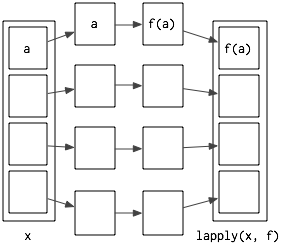

`lapply()` is written in C for performance, but we can create a simple R implementation that works the same way:

```r
lapply2 <- function(x, f, ...) {
  out <- vector("list", length(x))
  for (i in seq_along(x)) {
    out[[i]] <- f(x[[i]], ...)
  }
  out
}
```

From this code, you can see that `lapply()` is a wrapper around a common for loop pattern: we create a space for output, and then fill it in, applying `f()` to each component of the list. All other for loop functionals build on this base, modifying either the input, the output, or what data the function is applied to. From this code you can see that `lapply()` will also works with vectors: both `length()` and `'[[` work the same way for lists and vectors.

`lapply()` makes it easier to work with lists by eliminating much of the boilerplate, focussing on the operation you're applying to each piece:

```r
# Create some random data
l <- replicate(20, runif(sample(1:10, 1)), simplify = FALSE)

# With a for loop
out <- vector("list", length(l))
for (i in seq_along(l)) {
  out[[i]] <- length(l[[i]])
}
unlist(out)
```

```
##  [1]  5  2  3  7  7  5 10  6  5  4  2 10  8  2  8 10  8  5  2 10
```

```r
# With lapply
unlist(lapply(l, length))
```

```
##  [1]  5  2  3  7  7  5 10  6  5  4  2 10  8  2  8 10  8  5  2 10
```

(We're using `unlist()` to convert the output from a list to a vector to make the output more compact. We'll see other ways of making the output a vector shortly.)

Since data frames are also lists, `lapply()` is useful when you want to do something to each column of a data frame:

```r
# What class is each column?
unlist(lapply(mtcars, class))
```

```
##       mpg       cyl      disp        hp      drat        wt      qsec
## "numeric" "numeric" "numeric" "numeric" "numeric" "numeric" "numeric"
##        vs        am      gear      carb
## "numeric" "numeric" "numeric" "numeric"
```

```r
# Divide each column by the mean
mtcars[] <- lapply(mtcars, function(x) x / mean(x))
```

The pieces of `x` are always supplied as the first argument to `f`. You can override this using R's regular function calling semantics, supplying additional named arguments. For example, imagine you wanted to compute various trimmed means of the same dataset. `trim` is the second parameter of `mean()`, so we want to vary that, keeping the first argument (`x`) fixed. It's easy provided that you remember that the following two calls are equivalent

```r
mean(1:100, trim = 0.1)
```

```
## [1] 50.5
```

```r
mean(0.1, x = 1:100)
```

```
## [1] 50.5
```

So to use `lapply()` with the second argument, we just need to name the first argument:

```r
trims <- c(0, 0.1, 0.2, 0.5)
x <- rcauchy(100)
unlist(lapply(trims, mean, x = x))
```

[output not shown]

### Looping patterns

When using `lapply()` and friends, it's useful to remember that there are usually three ways to loop over an vector:

1. loop over the elements of the vector: `for(x in xs)`
2. loop over the numeric indices of the vector: `for(i in seq_along(xs))`
3. loop over the names of the vector: `for(nm in names(xs))`

If you're saving the results from a for loop, you usually can't use the first form because it makes very inefficient code. When extending an existing data structure, all the existing data must be copied every time you extend it:

```r
xs <- runif(1e3)
res <- c()
for(x in xs) {
  # This is slow!
  res <- c(res, sqrt(x))
}
```

It's much better to create enough space for the output and then fill it in, using the second looping form:

```r
res <- numeric(length(xs))
for(i in seq_along(xs)) {
  res[i] <- sqrt(xs[i])
}
```

Corresponding to the three ways to use a for loop there are three ways to use `lapply()` with an object:

```r
lapply(xs, function(x) {})
lapply(seq_along(xs), function(i) {})
lapply(names(xs), function(nm) {})
```

Typically you use the first form because `lapply()` takes care of saving the output for you. However, if you need to know the position or the name of the element you're working with, you'll need to use the second or third form; they give you both the position of the object (`i`, `nm`) and its value (`xs[[i]]`, `xs[[nm]]`). If you're struggling to solve a problem using one form, you might find it easier with a different form.

If you're working with a list of functions, remember to use `call_fun`:

```r
call_fun <- function(f, ...) f(...)
f <- list(sum, mean, median, sd)
lapply(f, call_fun, x = runif(1e3))
```

```
## [[1]]
## [1] 510.4
##
## [[2]]
## [1] 0.5104
##
## [[3]]
## [1] 0.5102
##
## [[4]]
## [1] 0.282
```

Or you could create a variant, `fapply()`, specifically for working with lists of functions:

```r
fapply <- function(fs, ...) {
  out <- vector("list", length(fs))
  for (i in seq_along(fs)) {
    out[[i]] <- fs[[i]](...)
  }
  out
}
fapply(f, x = runif(1e3))
```

```
## [[1]]
## [1] 508
##
## [[2]]
## [1] 0.508
##
## [[3]]
## [1] 0.5093
##
## [[4]]
## [1] 0.2809
```

### Exercises

- The function `scale01()` given below scales a vector to have range 0-1. How would you apply it to every column in a data frame? How would you apply it to every numeric column in a data frame?

```r
scale01 <- function(x) {
  rng <- range(x, na.rm = TRUE)
  (x - rng[1]) / (rng[2] - rng[1])
}
```

- For each formula in the list below, use a for-loop and lapply to fit the corresponding model to the `mtcars` dataset

```r
formulas <- list(
  mpg ~ disp,
  mpg ~ I(1 / disp),
  mpg ~ disp + wt,
  mpg ~ I(1 / disp) + wt
)
```

- Fit the model `mpg ~ disp` to each of the bootstrap replicates of `mtcars` in the list below, using a for loop and then `lapply()`. Can you do it without an anonymous function?

```r
bootstraps <- lapply(1:10, function(i) {
  rows <- sample(1:nrow(mtcars), rep = TRUE)
  mtcars[rows, ]
})
```

- For each model in the previous two exercises extract the R<sup>2</sup> using the function below.

```r
rsq <- function(mod) summary(mod)$r.squared
```

## For loop functionals: friends of `lapply()`

The art of using functionals is to recognise what common looping patterns are implemented in existing base functionals, and then use them instead of loops. Once you've mastered the existing functionals, the next step is to start writing your own: if you discover you're duplicating the same looping pattern in many places, you should extract it out into its own function.

The following sections build on `lapply()` and discuss:

- `sapply()` and `vapply()`, variants of `lapply()` that produce vectors, matrices and arrays as **output**, instead of lists.
- `Map()` and `mapply()` which iterate over multiple **input** data structures in parallel.
- **Parallel** versions of `lapply()` and `Map()`, `mclapply()` and `mcMap()`
- **Rolling computations**, showing how a new problem can be solved with for loops, or by building on top of `lapply()`.

### Vector output: `sapply` and `vapply`

`sapply()` and `vapply()` are very similar to `lapply()` except they will simplify their output to produce an atomic vector. `sapply()` guesses, while `vapply()` takes an additional argument specifying the output type. `sapply()` is useful for interactive use because it saves typing, but if you use it inside your functions you will get weird errors if you supply the wrong type of input. `vapply()` is more verbose, but gives more informative error messages and never fails silently, so is better suited for use inside other functions.

```r
sapply(mtcars, is.numeric)
```

```
##  mpg  cyl disp   hp drat   wt qsec   vs   am gear carb
## TRUE TRUE TRUE TRUE TRUE TRUE TRUE TRUE TRUE TRUE TRUE
```

```r
vapply(mtcars, is.numeric, logical(1))
```

```
##  mpg  cyl disp   hp drat   wt qsec   vs   am gear carb
## TRUE TRUE TRUE TRUE TRUE TRUE TRUE TRUE TRUE TRUE TRUE
```

```r
sapply(list(), is.numeric)
```

```
## list()
```

```r
vapply(list(), is.numeric, logical(1))
```

```
## logical(0)
```

If the function returns results of different types or lengths, `sapply()` will silently return a list, while `vapply()` will throw an error. `sapply()` is fine for interactive use because you'll normally notice if something went wrong, but it's dangerous when writing functions.

The following example illustrates a possible problem when extracting the class of columns in data frame: if you falsely assume that class only has one value and use `sapply()` you won't find out about the problem until some future function is given a list instead of a character vector.

```r
df <- data.frame(x = 1:10, y = letters[1:10])
sapply(df, class)
```

```
##         x         y
## "integer"  "factor"
```

```r
vapply(df, class, character(1))
```

```
##         x         y
## "integer"  "factor"
```

```r
df2 <- data.frame(x = 1:10, y = Sys.time() + 1:10)
sapply(df2, class)
```

```
## $x
## [1] "integer"
##
## $y
## [1] "POSIXct" "POSIXt"
```

```r
vapply(df2, class, character(1))
```

```
## Error: values must be length 1, but FUN(X[[2]]) result is length 2
```

`sapply()` is a thin wrapper around `lapply()`, transforming a list into a vector in the final step; `vapply()` reimplements `lapply()` but assigns results into a vector (or matrix) of the appropriate type instead of into a list. The following code shows pure R implementation of the essence of `sapply()` and `vapply()`; the real functions have better error handling and preserve names, among other things.

```r
sapply2 <- function(x, f, ...) {
  res <- lapply2(x, f, ...)
  simplify2array(res)
}

vapply2 <- function(x, f, f.value, ...) {
  out <- matrix(rep(f.value, length(x)), nrow = length(x))
  for (i in seq_along(x)) {
    res <- f(x[i], ...)
    stopifnot(
      length(res) == length(f.value),
      typeof(res) == typeof(f.value)
    )
    out[i, ] <- res
  }
  out
}
vapply2(1:10, f, logical(1))
```

```
## Error: typeof(res) == typeof(f.value) is not TRUE
```

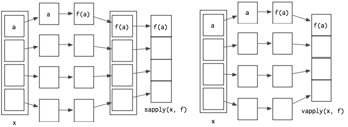

`vapply()` and `sapply()` are like `lapply()`, but with different outputs; the following section discusses `Map()`, which is like `lapply()` but with different inputs.

### Multiple inputs: `Map` (and `mapply`)

With `lapply()`, only one argument to the function varies; the others are fixed. This makes it poorly suited for some problems. For example, how would you find the weighted means when you have two lists, one of observations and the other of weights:

```r
# Generate some sample data
xs <- replicate(10, runif(10), simplify = FALSE)
ws <- replicate(10, rpois(10, 5) + 1, simplify = FALSE)
```

It's easy to use `lapply()` to compute the unweighted means:

```r
unlist(lapply(xs, mean))
```

```
##  [1] 0.5198 0.6977 0.5292 0.5111 0.5197 0.4936 0.4433 0.4107 0.5178 0.5983
```

But how could we supply the weights to `weighted.mean()`? `lapply(x, means, w)` won't work because the additional arguments to `lapply()` are passed to every call. We could change looping forms:

```r
unlist(lapply(seq_along(xs), function(i) {
  weighted.mean(xs[[i]], ws[[i]])
}))
```

```
##  [1] 0.4962 0.7034 0.5161 0.5342 0.5508 0.5059 0.4348 0.4279 0.5516 0.5716
```

This works, but is a little clumsy. A cleaner alternative is to use `Map`, a variant of `lapply()`, where all arguments vary. This lets us write:

```r
unlist(Map(weighted.mean, xs, ws))
```

```
##  [1] 0.4962 0.7034 0.5161 0.5342 0.5508 0.5059 0.4348 0.4279 0.5516 0.5716
```

(Note that the order of arguments is a little different: with `Map()` the function is the first argument, with `lapply()` it's the second.

This is equivalent to:

```r
stopifnot(length(x) == length(w))
out <- vector("list", length(x))
for (i in seq_along(x)) {
  out[[i]] <- weighted.mean(x[[i]], w[[i]])
}
```

There's a natural equivalence between `Map()` and `lapply()` because you can always convert a `Map()` to an `lapply()` that iterates over indices, but using `Map()` is more concise, and more clearly indicates what you're trying to do.

`Map` is useful whenever you have two (or more) lists (or data frames) that you need to process in parallel. For example, another way of standardising columns, is to first compute the means and then divide by them. We could do this with `lapply()`, but if we do it in two steps, we can more easily check the results at each step, which is particularly important if the first step is more complicated.

```r
mtmeans <- lapply(mtcars, mean)
mtmeans[] <- Map(`/`, mtcars, mtmeans)

# In this case, equivalent to
mtcars[] <- lapply(mtcars, function(x) x / mean(x))
```

If some of the arguments should be fixed, and not varying, you need to use an anonymous function:

```r
Map(function(x, w) weighted.mean(x, w, na.rm = TRUE), xs, ws)
```

We'll see a more compact way to express the same idea in the next chapter.

You may be more familiar with `mapply()` than `Map()`. I prefer `Map()` because:

- it is equivalent to `mapply` with `simplify = FALSE`, which is almost always what you want.
- Instead of using an anonymous function to provide constant inputs, `mapply` has the `MoreArgs` argument which takes a list of extra arguments that will be supplied, as is, to each call. This breaks R's usual lazy evaluation semantics, and is inconsistent with other functions.

In brief, `mapply()` is more complicated for little gain.

### Rolling computations

What if you need a for-loop replacement that doesn't exist in base R? You can often create your own by recognising common looping structures and implementing your own wrapper. For example, you might be interested in smoothing your data using a rolling (or running) mean function:

[figure not shown]

```r
rollmean <- function(x, n) {
  out <- rep(NA, length(x))

  offset <- trunc(n / 2)
  for (i in (offset + 1):(length(x) - n + offset - 1)) {
    out[i] <- mean(x[(i - offset):(i + offset - 1)])
  }
  out
}
x <- seq(1, 3, length = 1e2) + runif(1e2)
plot(x)
```

```r
lines(rollmean(x, 5), col = "blue", lwd = 2)
```

```
## Error: only 0's may be mixed with negative subscripts
```

```r
lines(rollmean(x, 10), col = "red", lwd = 2)
```

```
## Error: only 0's may be mixed with negative subscripts
```

But if the noise was more variable (i.e. it had a longer tail) you might worry that your rolling mean was too sensitive to the occasional outlier and instead implement a rolling median.

[figure not shown]

```r
x <- seq(1, 3, length = 1e2) + rt(1e2, df = 2) / 3
plot(x)
```

```r
lines(rollmean(x, 5), col = "red", lwd = 2)
```

```
## Error: only 0's may be mixed with negative subscripts
```

To modify `rollmean()` to `rollmedian()` all you need to do is replace `mean` with `median` inside the loop, but instead of copying and pasting to create a new function, we could extract the idea of computing a rolling summary into its own function:

[figure not shown]

```r
rollapply <- function(x, n, f, ...) {
  out <- rep(NA, length(x))

  offset <- trunc(n / 2)
  for (i in (offset + 1):(length(x) - n + offset - 1)) {
    out[i] <- f(x[(i - offset):(i + offset - 1)], ...)
  }
  out
}
plot(x)
```

```r
lines(rollapply(x, 5, median), col = "red", lwd = 2)
```

```
## Error: only 0's may be mixed with negative subscripts
```

You might notice that the internal loop looks pretty similar to a `vapply()` loop, so we could rewrite the function as:

```r
rollapply <- function(x, n, f, ...) {
  offset <- trunc(n / 2)
  locs <- (offset + 1):(length(x) - n + offset - 1)
  vapply(locs, function(i) f(x[(i - offset):(i + offset - 1)], ...),
    numeric(1))
}
```

This is effectively the same as the implementation in `zoo::rollapply()`, but it provides many more features and much more error checking.

### Parallelisation

One thing that's interesting about the defintions of `lapply()` is that because each iteration is isolated from all others, the order in which they are computed doesn't matter. For example, while `lapply3()`, defined below, scrambles the order in which computation occurs, the results are same every time:

```r
lapply3 <- function(x, f, ...) {
  out <- vector("list", length(x))
  for (i in sample(seq_along(x))) {
    out[[i]] <- f(x[[i]], ...)
  }
  out
}
unlist(lapply3(1:10, sqrt))
```

```
##  [1] 1.000 1.414 1.732 2.000 2.236 2.449 2.646 2.828 3.000 3.162
```

```r
unlist(lapply3(1:10, sqrt))
```

```
##  [1] 1.000 1.414 1.732 2.000 2.236 2.449 2.646 2.828 3.000 3.162
```

This has a very important consequence: since we can compute each element in any order, it's easy to dispatch the tasks to different cores, and compute in parallel. This is what `mclapply()` (and `mcMap`) in the parallel package do:

```r
library(parallel)
unlist(mclapply(1:10, sqrt, mc.cores = 4))
```

```
##  [1] 1.000 1.414 1.732 2.000 2.236 2.449 2.646 2.828 3.000 3.162
```

In this case `mclapply()` is actually slower than `lapply()`, because the cost of the individual computations is low, and some additional work is needed to send the computation to the different cores then collect the results together. If we take a more realistic example, generating bootstrap replicates of a linear model, we see more of an advantage:

```r
boot_df <- function(x) x[sample(nrow(x), rep = T), ]
rsquared <- function(mod) summary(mod)$r.square
boot_lm <- function(i) {
  rsquared(lm(mpg ~ wt + disp, data = boot_df(mtcars)))
}

system.time(lapply(1:500, boot_lm))
```

```
##    user  system elapsed
##   1.143   0.002   1.177
```

```r
system.time(mclapply(1:500, boot_lm, mc.cores = 2))
```

```
##    user  system elapsed
##   0.003   0.035   0.630
```

It is rare to get an exactly linear improvement with increasing number of cores, but if your code uses `lapply()` or `Map()`, this is an easy way to improve performance.